# Final Project - Lasso Model with Lambda

Author

Hong Fu

```
Required packages
```

```r
library(tidyverse)
library(caret)
library(glmnet)
library(ISLR)
library(Matrix)
```

# Abstract

The following model use Lasso with lambda to 1) dimension reduction statistically 2) cross validate performance results 3) display the performance matrix on accuracy, sensitivity, F1-score,

# Introduction

```r
Azhelmeimer_data <- read.csv("alzheimers_disease_data.csv")

# Remove rows with NA in Diagnosis
Azhelmeimer_data <- na.omit(Azhelmeimer_data)

# Using sapply to check the class of each column and retain numeric columns
Azhelmeimer_data <- Filter(is.numeric, Azhelmeimer_data)

# list of features
features <- colnames(Azhelmeimer_data)[-c(1,2)]
features <- features[features != "Diagnosis"]

# Set seed for reproducibility
set.seed(123)

# Train/Test split
train_indices <- createDataPartition(Azhelmeimer_data$Diagnosis, p = 0.6)[[1]]
train_data <- Azhelmeimer_data[train_indices,-c(1,2)]
test_data <- Azhelmeimer_data[-train_indices,-c(1,2)]

# Prepare the data matrices for glmnet
features <- features[-c(1,2)]
x_train <- as.matrix(train_data[, features])
y_train <- train_data$Diagnosis
x_test <- as.matrix(test_data[, features])
y_test <- test_data$Diagnosis
```

# Train a Lasso regression model with cross-validation and optimal lambda

```r
# Train a Lasso regression model with cross-validation to find the optimal lambda
lasso_cv <- cv.glmnet(x_train, y_train, alpha = 1)  # alpha = 1 for Lasso
optimal_lambda <- lasso_cv$lambda.min

# Fit the Lasso model using the optimal lambda
lasso_model <- glmnet(x_train, y_train, alpha = 1, lambda = optimal_lambda)
```

```r
# Function to calculate RMSE
calc_rmse <- function(model, x_test, y_test) {
  predictions <- predict(model, x_test)
  sqrt(mean((y_test - predictions)^2))
}

# Initial RMSE with the Lasso model using all features
initial_rmse <- calc_rmse(lasso_model, x_test, y_test)
cat("Initial RMSE with Lasso regression and all features include is :", sprintf("%.2f",initial_rmse), "\n")
```

```
Initial RMSE with Lasso regression and all features include is : 0.38
```

# Method (iii) - lasso approach with function of $\lambda$

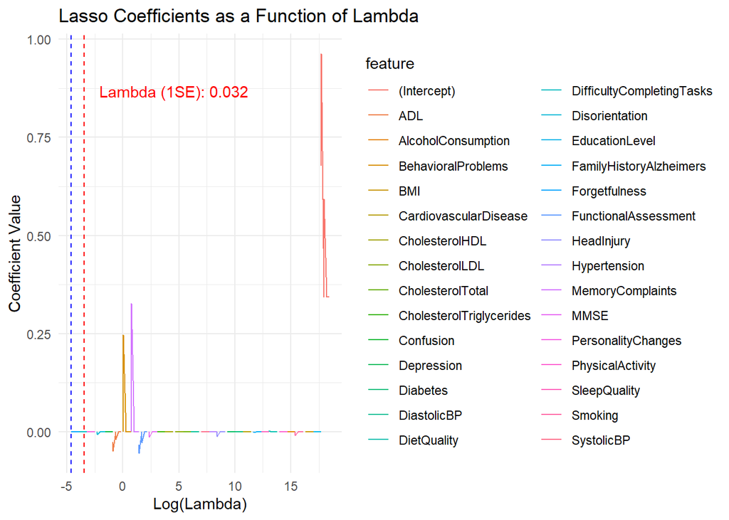

```r
# Load necessary libraries
library(glmnet)
library(tidyr)
library(ggplot2)

# Assume x_train and y_train are already defined

# Set a custom lambda grid for a wider range of values
grid <- 10^seq(8, -2, length = 100)

# Perform cross-validation to find the optimal lambda
lasso_cv <- cv.glmnet(x_train, y_train, alpha = 1, lambda = grid)

# Extract the best lambda value (lambda.min) and 1 SE
optimal_lambda <- lasso_cv$lambda.min
optimal_lambda_1se <- lasso_cv$lambda.1se    # Lambda within 1 SE of the minimum

# Fit the Lasso model using the full lambda grid
lasso_model <- glmnet(x_train, y_train, alpha = 1, lambda = grid)
lasso_coefs <- coef(lasso_model)

# Extract the coefficients from the Lasso model as a function of lambda
lasso_coefs <- as.matrix(lasso_coefs)

# Convert the coefficient matrix to a tidy format
coef_df <- as.data.frame(lasso_coefs)

# Create a 'feature' column for each feature name
coef_df$feature <- rownames(coef_df)

# Reshape the data to a long format using pivot_longer
coef_df_long <- coef_df %>%
  pivot_longer(cols = -feature, names_to = "lambda", values_to = "coefficient")

# Add the correct lambda values (repeated for each feature)
coef_df_long$lambda <- rep(grid, each = nrow(coef_df))

# Convert 'lambda' to numeric type (it might be a string after pivot_longer)
coef_df_long$lambda <- as.numeric(coef_df_long$lambda)

# Now create a plot with vertical lines for both optimal_lambda and optimal_lambda_1se
ggplot(coef_df_long, aes(x = log(lambda), y = coefficient, color = feature)) +
  geom_line() +
  labs(title = "Lasso Coefficients as a Function of Lambda",
       x = "Log(Lambda)", y = "Coefficient Value") +
  theme_minimal() +

  # Add vertical line for optimal lambda (lambda.min)
  geom_vline(xintercept = log(optimal_lambda), color = "blue", linetype = "dashed") +
  annotate("text", x = log(optimal_lambda), y = max(coef_df_long$coefficient),
           label = paste("Optimal Lambda (Min):", round(optimal_lambda, 4)),
           hjust = 1.2, color = "blue") +

  # Add vertical line for lambda.1se
  geom_vline(xintercept = log(optimal_lambda_1se), color = "red", linetype = "dashed") +
  annotate("text", x = log(optimal_lambda_1se), y = max(coef_df_long$coefficient) * 0.9,
           label = paste("Lambda (1SE):", round(optimal_lambda_1se, 4)),
           hjust = -0.1, color = "red")
```

The first dotted line (blue) is the optimal lambda (min). The second dotted line (red) is the 1 standard devication from the lambda (min). Both value should be used to detemine the optimum RMSE. In this example, optimal lambda min (blue) is the optimimum Log(Lambda) for best result.

## Model’s feature coefficients

Using the coefficients in the best model above and inspect which coefficients have been shrunk to zero i.e, to be removed to reduce a high dimensonal dataset. This is achieved through `cv.glmnet` will return the model fits for each $\lambda$ value. The coefficients for each $\lambda$ value for each features are calcuated and accessed using `cv.out$glmnet.fit$beta`.

```r
# Inspect the coefficients in the best model (at optimal lambda)
best_model_coefficients <- coef(lasso_cv, s = "lambda.min")

# Convert the sparse matrix of coefficients into a data frame for inspection
best_model_coefficients_df <- as.data.frame(as.matrix(best_model_coefficients))

# Rename the columns for better readability
colnames(best_model_coefficients_df) <- c("Coefficient")

# Add the feature names to the data frame
best_model_coefficients_df$Feature <- rownames(best_model_coefficients_df)

# Display the coefficients that have been shrunk to zero
zero_coefficients <- best_model_coefficients_df %>% filter(Coefficient == 0)

# Display the coefficients that have been shrunk to zero
cat("Features with coefficients shrunk to zero:\n")
```

```
Features with coefficients shrunk to zero:
```

```r
print(zero_coefficients)
```

```
                          Coefficient                   Feature
EducationLevel                      0            EducationLevel
BMI                                 0                       BMI
AlcoholConsumption                  0        AlcoholConsumption
CardiovascularDisease               0     CardiovascularDisease
Diabetes                            0                  Diabetes
Depression                          0                Depression
Hypertension                        0              Hypertension
SystolicBP                          0                SystolicBP
DiastolicBP                         0               DiastolicBP
CholesterolTotal                    0          CholesterolTotal
CholesterolHDL                      0            CholesterolHDL
Confusion                           0                 Confusion
PersonalityChanges                  0        PersonalityChanges
DifficultyCompletingTasks           0 DifficultyCompletingTasks
Forgetfulness                       0             Forgetfulness
```

```r
# Display the non-zero coefficients
non_zero_coefficients <- best_model_coefficients_df %>% filter(Coefficient != 0)

cat("\nFeatures with non-zero coefficients:\n")
```

```
Features with non-zero coefficients:
```

```r
print(non_zero_coefficients)
```

```
                           Coefficient                  Feature
(Intercept)               9.630945e-01              (Intercept)
Smoking                  -9.896604e-03                  Smoking
PhysicalActivity          5.550370e-04         PhysicalActivity
DietQuality               2.960476e-03              DietQuality
SleepQuality             -3.430514e-04             SleepQuality
FamilyHistoryAlzheimers  -6.963491e-04  FamilyHistoryAlzheimers
HeadInjury               -1.240885e-02               HeadInjury
CholesterolLDL           -2.914355e-04           CholesterolLDL
CholesterolTriglycerides  8.543064e-05 CholesterolTriglycerides
MMSE                     -1.312074e-02                     MMSE
FunctionalAssessment     -5.429705e-02     FunctionalAssessment
MemoryComplaints          3.271896e-01         MemoryComplaints
BehavioralProblems        2.463606e-01       BehavioralProblems
ADL                      -4.915018e-02                      ADL
Disorientation           -6.344683e-03           Disorientation
```

```r
# Use the best CV model to predict the test set Salary
# Use the best CV model (with optimal lambda) to predict the Salary on the test set
test_predictions <- predict(lasso_cv, newx = x_test, s = "lambda.min")

# Calculate the Mean Squared Error (MSE) on the test set
test_mse <- mean((y_test - test_predictions)^2)

# Display the test MSE
cat("Sqaure Root of Mean Squared Error on the test set:", sprintf("%.2f",sqrt(test_mse)), "\n")
```

```
Sqaure Root of Mean Squared Error on the test set: 0.38
```

## Model performance on test data

```r
# Load required packages
library(glmnet)
library(caret)  # For confusionMatrix

# Assume x_test and y_test are already defined

# Predict on the test data using the best lambda from cross-validation
predictions_prob <- predict(lasso_cv, s = "lambda.min", newx = x_test, type = "response")

# Convert probabilities to binary class predictions (threshold = 0.5)
predictions <- ifelse(predictions_prob >= 0.5, 1, 0)

# Convert predictions and y_test to factors for caret compatibility
predictions <- factor(predictions, levels = c(0, 1))
y_test <- factor(y_test, levels = c(0, 1))

# Create confusion matrix to get accuracy, sensitivity, and specificity
conf_matrix <- confusionMatrix(predictions, y_test)

# Display accuracy, sensitivity, specificity
cat("Accuracy:", conf_matrix$overall["Accuracy"], "\n")
```

```
Accuracy: 0.8183935
```

```r
cat("Sensitivity (Recall):", conf_matrix$byClass["Sensitivity"], "\n")
```

```
Sensitivity (Recall): 0.898524
```

```r
cat("Specificity:", conf_matrix$byClass["Specificity"], "\n")
```

```
Specificity: 0.681388
```

```r
cat("Precision:", conf_matrix$byClass["Precision"], "\n")
```

```
Precision: 0.8282313
```

```r
# Calculate F1-score
precision <- conf_matrix$byClass["Precision"]
recall <- conf_matrix$byClass["Sensitivity"]
F1_score <- 2 * (precision * recall) / (precision + recall)

cat("F1 Score:", F1_score, "\n")
```

```
F1 Score: 0.8619469
```

# Conclusion